# Администрирование локальных сетей

Лабораторная работа №13

Илья Колонтырский

Российский университет дружбы народов, Москва, Россия

2 мая 2026

# Цели и задачи работы

## Цель лабораторной работы

Провести подготовительные мероприятия по организации взаимодействия через сеть провайдера посредством статической маршрутизации локальной сети с:

- сетью основного здания, расположенного в **42-м квартале в Москве**;
- сетью филиала, расположенного **в г. Сочи**.

## Задачи

- Добавить в проект подсеть 42-го квартала в Москве.
- Добавить в проект подсеть филиала в г. Сочи.
- Обновить схемы **L1**, **L2** и **L3**.
- Разместить новые объекты на физической карте проекта.
- Выполнить первоначальную настройку добавленного оборудования.
- Подготовить проект к дальнейшей настройке статической маршрутизации.

# Архитектура сети L1–L3

## Уровень L1 — физическая топология

На уровне L1 показана физическая структура сети:

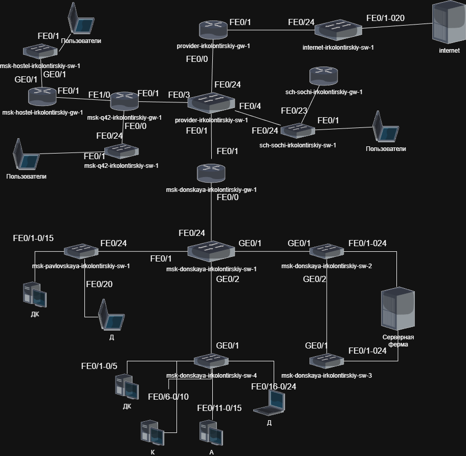

L1: физическая структура сети с основной территорией в Москве и филиалом в Сочи

## Уровень L2 — VLAN и trunk/access

На уровне L2 отображено распределение VLAN между участками сети.

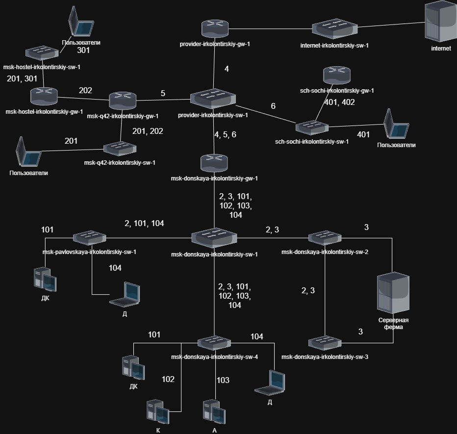

## Уровень L3 — IP-план

На уровне L3 выполнено логическое разбиение сети по IP-подсетям.

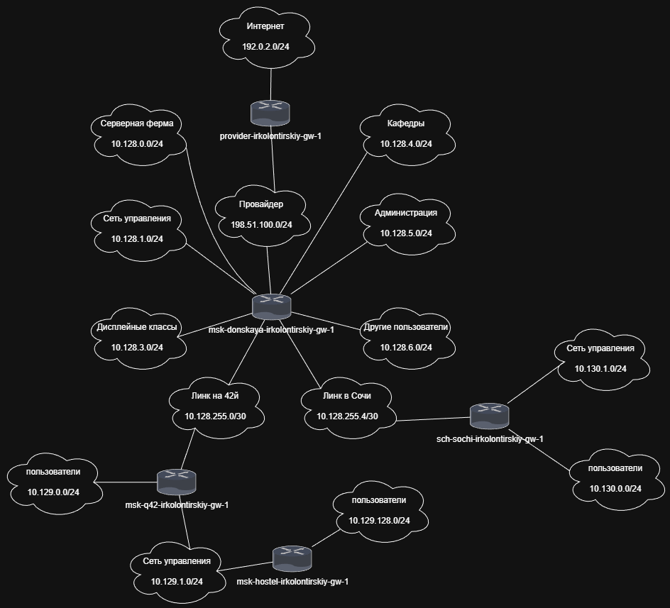

L3: IP-план сети основной площадки, 42-го квартала и филиала в Сочи

# Размещение объектов

## Общая карта проекта

На общей карте отображены две удалённые территории, соединённые линией связи.

Нижняя область соответствует основной территории организации, а верхняя область — удалённой площадке. Такое представление показывает, что проект строится как распределённая корпоративная сеть.

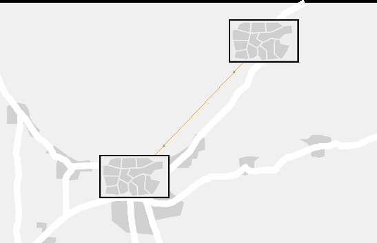

Общая карта размещения территорий проекта

## Основная территория организации

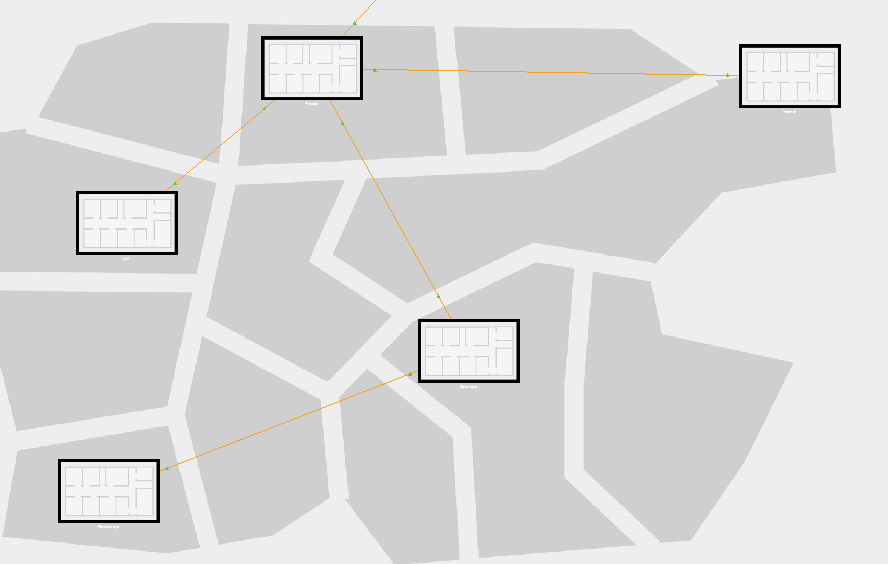

Размещение объектов основной территории организации

## Подсеть 42-го квартала в Москве

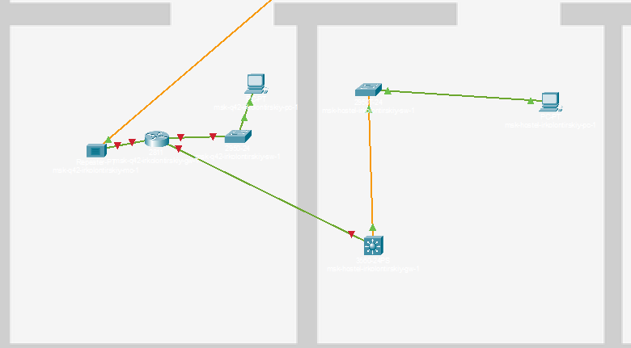

Физическая схема подсети 42-го квартала в Москве

## Подсеть филиала в г. Сочи

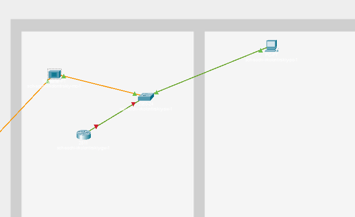

Физическая схема подсети филиала в г. Сочи

## Итоговая логическая топология

[figure not shown]

Итоговая логическая топология проекта с подсетями 42-го квартала и филиала в Сочи

# Первоначальная настройка оборудования

## Выполненные действия

На добавленных устройствах была выполнена единая базовая настройка:

- назначение имени устройства;
- настройка пароля для консольного доступа;
- настройка пароля для удалённого доступа через VTY;
- включение авторизации;
- настройка **enable secret**;
- включение шифрования паролей;
- создание пользователя **admin**;
- настройка доменного имени;
- генерация RSA-ключей;
- включение доступа по SSH;
- сохранение конфигурации.

## Настройка оборудования 42-го квартала

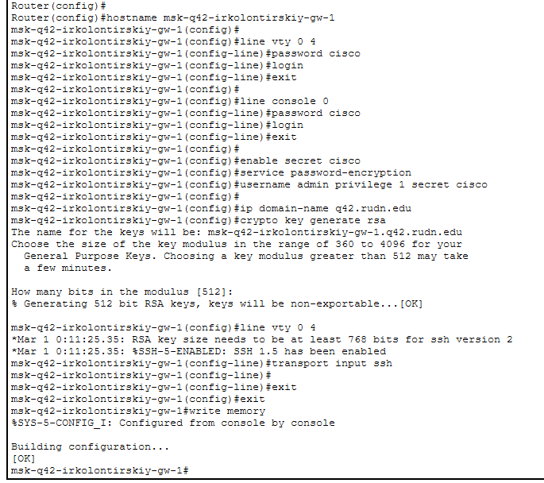

Первоначальная настройка маршрутизатора msk-q42-irkolontirskiy-gw-1

## Настройка msk-q42-irkolontirskiy-sw-1

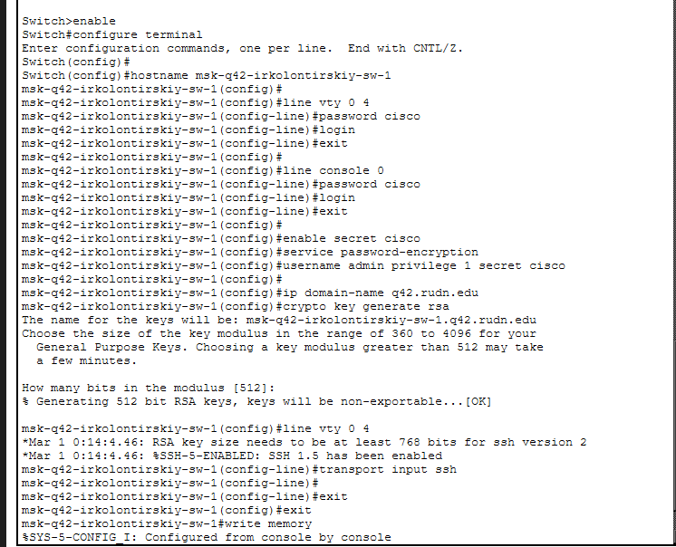

Первоначальная настройка коммутатора msk-q42-irkolontirskiy-sw-1

## Настройка msk-hostel-irkolontirskiy-gw-1

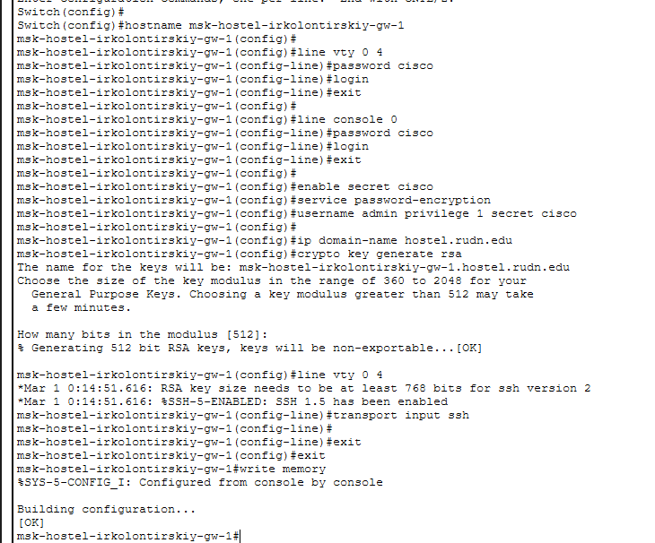

Первоначальная настройка маршрутизатора msk-hostel-irkolontirskiy-gw-1

## Настройка msk-hostel-irkolontirskiy-sw-1

[figure not shown]

Первоначальная настройка коммутатора msk-hostel-irkolontirskiy-sw-1

## Настройка sch-sochi-irkolontirskiy-sw-1

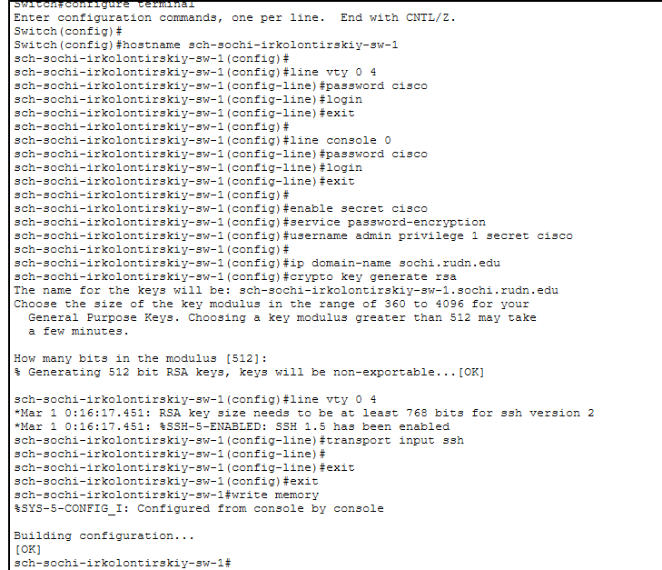

Первоначальная настройка коммутатора sch-sochi-irkolontirskiy-sw-1

## Настройка sch-sochi-irkolontirskiy-gw-1

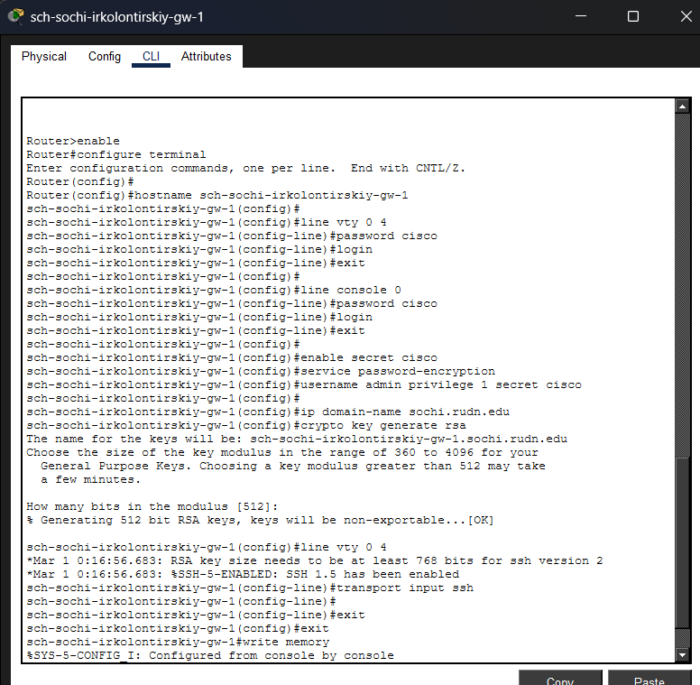

Первоначальная настройка маршрутизатора sch-sochi-irkolontirskiy-gw-1

# Выводы

## Вывод

В ходе лабораторной работы структура сетевого проекта была расширена.

В общую корпоративную сеть были добавлены:

- подсеть основной территории организации **42-го квартала в Москве**;
- подсеть **общежития**;
- подсеть филиала **в г. Сочи**.

Для новых сегментов были обновлены схемы **L1**, **L2** и **L3**, а также выполнена первоначальная настройка добавленного оборудования.